# Conceptos de intervalos de confianza

# Concepto

Rango de valores, entre los que tenemos gran confianza de incluir al parámetro buscado.

```r
a <- rnorm(10,0,1)
b <- rnorm(10,0,1)
punto <- data.frame(mean(a),
mean(b))
```

```r
cnormal <- ggplot(data.frame(x = c(-4, 4)), aes(x = x)) +
      stat_function(fun = dt, args = list(df = 20)) +
      scale_x_continuous(breaks=0, labels="0") +
      xlab(NULL) +
      theme_bw()
cnormal + geom_point(data=punto, aes(x=a), size=4)
```

```
Error: Aesthetics must be either length 1 or the same as the data (1): x
Run `rlang::last_error()` to see where the error occurred.
```

# Interpretación de los intervalos de confianza

En primer lugar, genero las 100 muestras, calculo la media y sus intervalos de confianza al 95%. La media=50, y la desviación típica=10.

```r
set.seed(403)
id.m <- seq(1,100)
media <- numeric(100)
varianza <- numeric(100)
lci <- numeric(100)
lcs <- numeric(100)
for(i in 1:100){
  muestra <- rnorm(100,50,10)
  media[i] <- round(mean(muestra),1)
  varianza[i] <- var(muestra)
  lci[i] <- round(media[i]-1.96,1) #Error típico=1
  lcs[i] <- round(media[i]+1.96,1)
}
intconf <- data.frame(id.m,media, lci, lcs)
```

Identificamos los intervalos que no incluyen el valor de la media. El siguiente gráfico representa los i.c. de las 100 muestras:

```r
intconf <- intconf %>%
  mutate(incluye=ifelse((lci>50|lcs<50),1,0))
intconf$incluye <- as.factor(intconf$incluye)
# intconf$incluye <- factor(intconf$incluye, levels="No","Sí")
# table(intconf$incluye)
```

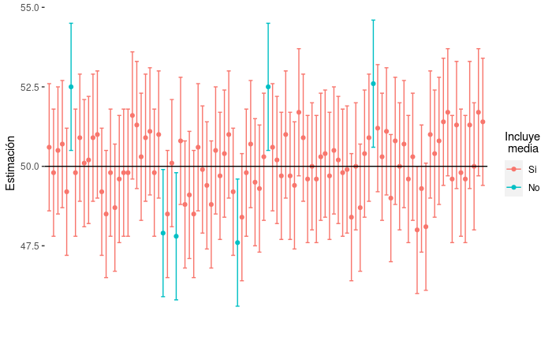

```r
ggplot(intconf, aes(id.m, media, ymin=lci, ymax=lcs, colour=incluye))+
  geom_errorbar() +
  geom_point(aes(y=media)) +
  geom_hline(yintercept = 50) +
  scale_x_discrete(labels=NULL) +
  xlab("") +
  ylab("Estimación")+
  scale_colour_discrete(name = "Incluye\n media", labels = c("Si", "No")) +
  theme( panel.border = element_blank(),
  panel.grid = element_blank(),
  panel.background = element_blank())
ggsave("~/material_docente/intervalosconfianza/intconf1.png")
```

Hay un comando de R para [simular muestras](http://search.r-project.org/library/PASWR2/html/cisim.html)

```r
PASWR2::cisim(samples = 100, n = 30, parameter = 20, sigma = 5,
  conf.level = 0.95)
#parameter = media
#sigma = desviación típica
# Por defecto, para la media
# Para la varianza, escribir type="Var"
# Para la binomial, escribir type="Pi"
```

##Influencia del nivel de confianza  
Generamos una muestra, de tamaño 25, y calculamos los intervalos al 50%, 90%, 95% y 99%. Los parámetros poblacionales son los mismos que en el primer diagrama. Los niveles de confianza tienen los siguientes valores: - 50%: 0.67  
- 90%: 1.64  
- 95%: 1.96  
- 99%: 2.57

```r
set.seed(1234)
muestra <- rnorm(25,50,10)
id.ic <- 1:4
#id.ic <- factor(id.ic, levels=c("50%", "90%", "95%", "99%"))
media <- mean(muestra)
et <- c(1.34,3.28,3.92,5.15)
intconf2 <- data.frame(id.ic, media, lci, lcs)
```

El gráfico de los cuatro intervalos muestra las distintas amplitudes, según el nivel de confianza usado en cada uno.

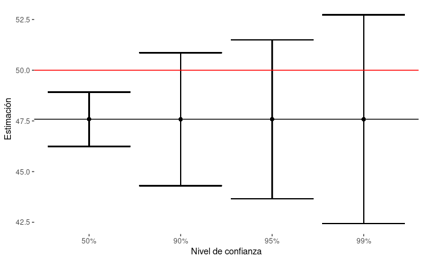

```r
ggplot(intconf2, aes(factor(id.ic), media, ymin=media-et, ymax=media+et))+
  geom_errorbar() +
  geom_point(aes(y=media)) +
  geom_hline(yintercept = 50, colour="red") +
  geom_hline(yintercept = media) +
  scale_x_discrete("Nivel de confianza", labels=c("50%", "90%", "95%", "99%")) +
  xlab("") +
  ylab("Estimación")+
  theme(
  panel.border = element_blank(),
  panel.grid = element_blank(),
  panel.background = element_blank())
ggsave("~/material_docente/intervalosconfianza/intconf2.png")
```

La muestra es la misma en cada caso, y la estimación de la media (47,5), que aparece señalada con una línea horizontal. Pero hemos obtenido cuatro intervalos, con un nivel de confianza diferente. El primero, al 50%, es mucho más estrecho que los restantes. Y también es el único que no incluye al valor de la media poblacional (50), señalada con una línea horizontal de color rojo. Vemos que, al aumentar el nivel de confianza, aumenta la amplitud del intervalo. Y al hacerlo, consiguen incluir al valor de la media poblacional.

## Influencia del tamaño de la muestra

Generamos muestras muestra de distintos tamaños. Calculamos los intervalos al 95% . Los parámetros poblacionales son los mismos que en el primer diagrama. Los niveles de confianza tienen los siguientes valores: - n = 5  
- n = 10  
- n = 25  
- n = 100  
- n = 500

```r
set.seed(-1633235281)
tamano <- c(5,10,25,100,500)
media <- c(mean(rnorm(5,50,10)),
           mean(rnorm(10,50,10)),
           mean(rnorm(25,50,10)),
           mean(rnorm(100,50,10)),
           mean(rnorm(500,50,10)))
et <- c(10/sqrt(5),10/sqrt(10),2,1,10/sqrt(500))
intconf3 <- data.frame(tamano, media, et)
```

Y ahora construimos el gráfico. El ejer horizontal se tiene que representar logarítmicamente.

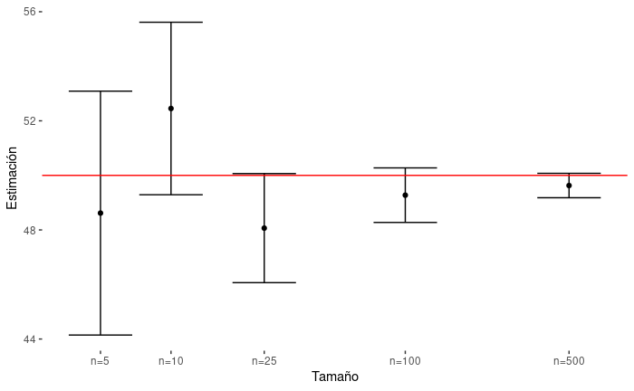

```r
ggplot(intconf3, aes(tamano, media, ymin=media-et, ymax=media+et))+
  geom_errorbar() +
  geom_point(aes(y=media)) +
  geom_hline(yintercept = 50, colour="red") +
  scale_x_continuous("Tamaño", breaks=c(5,10,25,100,500),labels=c("n=5", "n=10", "n=25", "n=100", "n=500"), trans = "log10") +
  ylab("Estimación")+
  theme(
  panel.border = element_blank(),
  panel.grid = element_blank(),
  panel.background = element_blank())
ggsave("~/material_docente/intervalosconfianza/intconf3.png")
```

En este caso, todos los intervalos incluyen al valor 50, que es el que toma la media de la población. Pero no tiene por qué ser así siempre; podría ocurrir que algunos intervalos incluyeran el valor de la media poblacional, y que otros no lo hicieran. Por eso los llamamos intervalos de *confianza* en vez de llamarlos intervalos de *certeza*.  
Debemos comentar algunos aspectos que se deducen del gráfico:  
- Como era de esperar, la amplitud del intervalo se estrecha cuando lo calculamos para muestras de mayor tamaño.  
- Los valores de las medias muestrales están más cerca, en general, de la media poblacional. Pero en el caso de la segunda muestra, n=10, la estimación está más lejos que la encontrada en el primer caso. Esto no contradice las bases de la inferencia, porque la selección aleatoria conduce a ese tipo de variabilidad.  
- Dentro de cada intervalo, el valor de la media poblacional lo podemos encontrar en lugares diferentes. En el primer intervalo, está en la parte media; en el segundo, está cerca del límite inferior; en el tercero, coincide con el límite superior del intervalo, … Esto es también esperable, por el mismo motivo que se ha mencionado antes: la variabilidad por la selección aleatoria.

## Diferencia de medias

```r
# Datos inspirados en Bland y Altma: Statistics with confidence
grupo1 <- round(rnorm(50,146.4,2.5),1)
grupo2 <- round(rnorm(50,140.4,2.5),1)
ensayo <- data.frame(tto=c(rep("Diabetico",50) , rep("No diabetico",50)),
                     medida=c(grupo1,grupo2))
intervalo <- data.frame(x=3,
                        diferencia=142.0,
                        etipico=sqrt(2/100*2.5^2)
                        )
```

[figure not shown]